# Exploratory Data Analysis and Logistic Regression

# ROC Curves

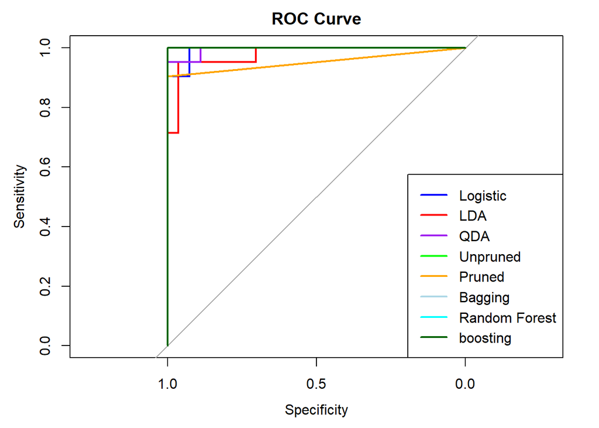

```
##
## AUC for Models:
```

```
## Logistic Regression:  0.9929453
```

```
## LDA:  0.9770723
```

```
## QDA:  0.994709
```

```
## Unpruned Decision Tree:  0.952381
```

```
## Pruned Decision Tree:  0.952381
```

```
## Bagging (Random Forest):  1
```

```
## Random Forest:  1
```

```
## XGBoost:  1
```

In addition, we plotted the ROC curve and calculated the AUC value of different models in order to assess their performance. And the results reinforced that the Random forest outperform all other models. However, it has the same performance as in boosting and bagging random forests.

This project has provided us with valuable hands-on experience in learning the R programming language and exploring various libraries commonly used in machine learning. Throughout the project, we gained insights into how to train different classification models and assess their performance. As this is our first time applying the concepts learned in the Data Mining course, we recognize that the project requires several adjustments and improvements. We would greatly appreciate detailed feedback to help refine our approach and further enhance our data analysis skills.